# 1. - Bajar información relevante

```python
import sys
import pandas as pd
import numpy as np
import sklearn
from sklearn.pipeline import Pipeline
from sklearn import metrics
import category_encoders as ce
from sklearn.preprocessing import OneHotEncoder
from sklearn.ensemble import GradientBoostingClassifier
import matplotlib.pyplot as plt
import seaborn as sns
```

```python
df_loan_train = pd.read_csv('../data/processed_data/train_data_processed.csv')
df_loan_test = pd.read_csv('../data/processed_data/test_data_processed.csv')
df_loan_test.head()
```

|  | SK_ID_CURR | NAME_CONTRACT_TYPE | CODE_GENDER | FLAG_OWN_CAR | FLAG_OWN_REALTY | CNT_CHILDREN | AMT_INCOME_TOTAL | AMT_CREDIT | AMT_ANNUITY | AMT_GOODS_PRICE | ... | FLAG_DOCUMENT_19 | FLAG_DOCUMENT_20 | FLAG_DOCUMENT_21 | TARGET | AMT_REQ_CREDIT_BUREAU_HOUR_input | AMT_REQ_CREDIT_BUREAU_DAY_input | AMT_REQ_CREDIT_BUREAU_WEEK_input | AMT_REQ_CREDIT_BUREAU_MON_input | AMT_REQ_CREDIT_BUREAU_QRT_input | AMT_REQ_CREDIT_BUREAU_YEAR_input |
| --- | --- | --- | --- | --- | --- | --- | --- | --- | --- | --- | --- | --- | --- | --- | --- | --- | --- | --- | --- | --- | --- |
| 0 | 171458 | Cash loans | F | N | N | 0.0 | 121500.0 | 269550.0 | 21294.0 | 225000.0 | ... | 0 | 0 | 0 | 0 | 0.0 | 0.0 | 0.0 | 0.0 | 2.0 | 1.0 |
| 1 | 213619 | Cash loans | M | N | Y | 0.0 | 99000.0 | 526491.0 | 17527.5 | 454500.0 | ... | 0 | 0 | 0 | 0 | 0.0 | 0.0 | 0.0 | 0.0 | 0.0 | 4.0 |
| 2 | 135905 | Cash loans | F | N | N | 1.0 | 135000.0 | 450000.0 | 35554.5 | 450000.0 | ... | 0 | 0 | 0 | 0 | 0.0 | 0.0 | 0.0 | 0.0 | 2.0 | 1.0 |
| 3 | 345017 | Cash loans | M | Y | N | 0.0 | 157500.0 | 253737.0 | 24849.0 | 229500.0 | ... | 0 | 0 | 0 | 0 | 0.0 | 0.0 | 0.0 | 0.0 | 0.0 | 2.0 |
| 4 | 155332 | Cash loans | M | N | Y | 0.0 | 49500.0 | 273636.0 | 15705.0 | 247500.0 | ... | 0 | 0 | 0 | 0 | 0.0 | 0.0 | 0.0 | 0.0 | 2.0 | 1.0 |

5 rows × 106 columns

# 2. - Codificación variables categóricas

La codificación de variables categóricas tiene como propósito transformar datos categóricos en un formato numérico que pueda ser entendido y procesado por algoritmos de machine learning. Dado que la mayoría de los modelos estadísticos y de machine learning no trabajan directamente con datos no numéricos, es necesario convertir las categorías en representaciones matemáticas. La codificación garantiza que estas transformaciones preserven las relaciones y patrones subyacentes en los datos, minimizando la pérdida de información.

Tipos de Codificación

1. **One-Hot Encoding**
   - Consiste en: Crear una nueva columna binaria (0/1) para cada categoría en la variable original. Si una fila pertenece a una categoría, la columna correspondiente toma el valor 1; de lo contrario, toma 0.
   - Se suele aplicar: A variables categóricas nominales (sin orden inherente), como colores, ciudades, o marcas. Es ideal para variables con pocas categorías.
   - Ejemplo: La categoría "Color" con valores {Rojo, Azul, Verde} generaría tres columnas: "Color_Rojo", "Color_Azul", "Color_Verde".
2. **Label Encoding**
   - Consiste en: Asignar un número entero a cada categoría de la variable (e.g., "Rojo" = 0, "Azul" = 1, "Verde" = 2).
   - Se suele aplicar: A variables categóricas ordinales (donde existe un orden lógico entre categorías), como niveles educativos ("Bajo", "Medio", "Alto").
   - Ejemplo: La categoría "Tamaño" con valores {Pequeño, Mediano, Grande} podría codificarse como {0, 1, 2}, respetando el orden inherente.
3. **Binary Encoding**
   - Consiste en: Convertir las categorías en valores binarios y utilizar las posiciones binarias como columnas. Este método reduce el número de columnas en comparación con One-Hot Encoding.
   - Se suele aplicar: A variables con alta cardinalidad (muchas categorías) para reducir la dimensionalidad mientras se preserva información.
   - Ejemplo: Una categoría con valores {1, 2, 3, 4} podría transformarse en sus representaciones binarias: {00, 01, 10, 11}.
4. **Target Encoding (Codificación Basada en el Objetivo)**
   - Consiste en: Sustituir cada categoría por una estadística calculada a partir de la variable objetivo (e.g., media, proporción o mediana de la categoría con respecto al objetivo).
   - Se suele aplicar: En problemas supervisados donde la variable objetivo está disponible, y particularmente útil para variables categóricas con alta cardinalidad.
   - Ejemplo: Si la variable objetivo es binaria (0/1), la categoría "A" podría reemplazarse con la proporción de 1 dentro de esa categoría.
5. **Frequency Encoding**
   - Consiste en: Sustituir cada categoría por la frecuencia relativa o absoluta con la que aparece en la columna.
   - Se suele aplicar: A variables categóricas con muchas categorías, especialmente cuando la frecuencia tiene un significado relevante en el análisis.
   - Ejemplo: Si la categoría "A" aparece en el 50% de las filas, se codificaría con el valor 0.5.
6. **Hashing Encoding**
   - Consiste en: Aplicar una función hash para asignar cada categoría a un espacio reducido de columnas, basado en el resultado del hash. No requiere conocer todas las categorías por adelantado.
   - Se suele aplicar: A datasets muy grandes con variables categóricas de muy alta cardinalidad, o en sistemas en tiempo real donde las categorías no son fijas.
   - Ejemplo: La categoría "Rojo" podría mapearse a un hash único como columna binaria dentro de un espacio reducido.

## 2.1. - Análisis

```python
lista_variables_codificar = df_loan_train.select_dtypes('object').columns.to_list()
df_loan_train[lista_variables_codificar].nunique()
```

```
NAME_CONTRACT_TYPE             2
CODE_GENDER                    3
FLAG_OWN_CAR                   2
FLAG_OWN_REALTY                2
NAME_TYPE_SUITE                7
NAME_INCOME_TYPE               8
NAME_EDUCATION_TYPE            5
NAME_FAMILY_STATUS             6
NAME_HOUSING_TYPE              6
OCCUPATION_TYPE               19
WEEKDAY_APPR_PROCESS_START     7
ORGANIZATION_TYPE             58
HOUSETYPE_MODE                 4
WALLSMATERIAL_MODE             8
EMERGENCYSTATE_MODE            3
dtype: int64
```

```python
df_loan_train.WEEKDAY_APPR_PROCESS_START.value_counts()
```

```
WEEKDAY_APPR_PROCESS_START
TUESDAY      43114
WEDNESDAY    41585
MONDAY       40624
THURSDAY     40523
FRIDAY       40168
SATURDAY     27103
SUNDAY       12891
Name: count, dtype: int64
```

He decidido aplicar diferentes tipos de codificación en función de las características específicas de las variables categóricas de mi dataset para maximizar la información que aportan al modelo, manteniendo la simplicidad y evitando introducir relaciones artificiales.

## 2.2. - Proceso de codificación

```python
## SK_ID_CURR es un identificador: no debe entrar como variable del modelo
X_train = df_loan_train.drop(['TARGET', 'SK_ID_CURR'], axis=1)
X_test = df_loan_test.drop(['TARGET', 'SK_ID_CURR'], axis=1)
y_train = df_loan_train['TARGET']
y_test = df_loan_test['TARGET']
```

```python
## LABEL ENCODING

from sklearn.preprocessing import LabelEncoder

# Crear el codificador
label_encoder = LabelEncoder()

# Aplicar Label Encoding en WEEKDAY_APPR_PROCESS_START en el conjunto de entrenamiento
X_train['WEEKDAY_APPR_PROCESS_START'] = label_encoder.fit_transform(X_train['WEEKDAY_APPR_PROCESS_START'])

# Aplicar el mismo mapeo en el conjunto de prueba
X_test['WEEKDAY_APPR_PROCESS_START'] = label_encoder.transform(X_test['WEEKDAY_APPR_PROCESS_START'])

# Verificar el resultado
print("Valores únicos tras codificación en entrenamiento:", X_train['WEEKDAY_APPR_PROCESS_START'].unique())
print("Valores únicos tras codificación en prueba:", X_test['WEEKDAY_APPR_PROCESS_START'].unique())
```

```
Valores únicos tras codificación en entrenamiento: [3 6 1 5 4 0 2]
Valores únicos tras codificación en prueba: [4 3 5 2 6 0 1]
```

```python
### TARGET ENCODING
import category_encoders as ce

# Variables a codificar
target_columns = ['ORGANIZATION_TYPE', 'OCCUPATION_TYPE']

# Crear y ajustar el codificador de Target Encoding
target_enc = ce.TargetEncoder(cols=target_columns)
target_enc.fit(X_train[target_columns], y_train)  # Ajustar usando el conjunto de entrenamiento

# Transformar directamente X_train y X_test
X_train[target_columns] = target_enc.transform(X_train[target_columns])
X_test[target_columns] = target_enc.transform(X_test[target_columns])


# Verificar formas finales y primeras filas
print("Formas finales:", X_train.shape, X_test.shape)
print("Primeras filas de entrenamiento:\n", X_train[target_columns].head())
print("Primeras filas de prueba:\n", X_test[target_columns].head())


lista_variables_codificar.remove('ORGANIZATION_TYPE')
lista_variables_codificar.remove('OCCUPATION_TYPE')
lista_variables_codificar.remove('WEEKDAY_APPR_PROCESS_START')
```

```
Formas finales: (246008, 104) (61503, 104)
Primeras filas de entrenamiento:
    ORGANIZATION_TYPE  OCCUPATION_TYPE
0           0.093540         0.114073
1           0.085501         0.105268
2           0.105896         0.109633
3           0.085501         0.105268
4           0.053737         0.064711
Primeras filas de prueba:
    ORGANIZATION_TYPE  OCCUPATION_TYPE
0           0.059254         0.063856
1           0.101054         0.176295
2           0.065738         0.066804
3           0.052298         0.063711
4           0.053737         0.064711
```

```python
import category_encoders as ce
import json

# Categorías originales tomadas de df_loan_train: X_train ya tiene ORGANIZATION_TYPE codificada
# y no hay que sobrescribirla (si no, la columna vuelve a ser texto y el escalado falla)
organization_type_raw = df_loan_train[['ORGANIZATION_TYPE']]

# Crear y ajustar el codificador de Target Encoding
target_enc_org = ce.TargetEncoder(cols=['ORGANIZATION_TYPE'])
target_enc_org.fit(organization_type_raw, y_train)  # Ajustar usando el conjunto de entrenamiento

# Obtener las categorías originales con sus valores codificados (una fila por categoría)
organization_type_mapping = organization_type_raw.drop_duplicates().reset_index(drop=True)
organization_type_mapping['target_mean'] = target_enc_org.transform(organization_type_mapping[['ORGANIZATION_TYPE']])['ORGANIZATION_TYPE']

# Convertir a diccionario
organization_type_encoding = dict(zip(organization_type_mapping['ORGANIZATION_TYPE'], organization_type_mapping['target_mean']))
# Guardar en un archivo JSON
with open('../data/variables/organization_type_encoding.json', 'w') as f:
    json.dump(organization_type_encoding, f, indent=4)
```

```python
### One-hot encding

# Crear y aplicar One-Hot Encoder
ohe = ce.OneHotEncoder(cols=lista_variables_codificar, use_cat_names=True)
ohe.fit(X_train, y_train)

# Transformar X_train y X_test
X_train = ohe.transform(X_train)
X_test = ohe.transform(X_test)

# Verificar formas finales
print(X_train.shape, X_test.shape)
```

```
(246008, 148) (61503, 148)
```

```python
import os
# variables_modelo.txt lo escribe el notebook 04: en una ejecución desde cero todavía no existe
ruta_variables_modelo = '../data/variables/variables_modelo.txt'
variables = []
if os.path.exists(ruta_variables_modelo):
    with open(ruta_variables_modelo, 'r') as file:
        variables = [line.strip() for line in file]  # Elimina espacios en blanco y saltos de línea
    variables = [v for v in variables if v in X_train.columns]
```

```python
print("Forma de X_train:", X_train.shape)
print("Forma de y_train:", y_train.shape)
```

```
Forma de X_train: (246008, 148)
Forma de y_train: (246008,)
```

```python
y_train = pd.DataFrame(y_train, columns=['TARGET'])  # Reemplaza 'TARGET' por el nombre real
df_vars = X_train[variables]

# Concatenar X_train e y_train
train_data = pd.concat([df_vars, y_train], axis=1)
```

```python
## Configuro la visualización de mis datasets
pd.set_option('display.max_columns', 500)
pd.set_option('display.max_rows', 500)
train_data[train_data['TARGET'] == 1 ]
```

|  | TARGET |
| --- | --- |
| 10 | 1 |
| 16 | 1 |
| 26 | 1 |
| 41 | 1 |
| 51 | 1 |
| ... | ... |
| 245968 | 1 |
| 245971 | 1 |
| 245972 | 1 |
| 245973 | 1 |
| 245983 | 1 |

19860 rows × 1 columns

# 3. - Escalado de variables

El escalado de variables tiene como objetivo normalizar o estandarizar las características del dataset para garantizar que todas tengan un rango similar o comparable. Esto es especialmente importante en algoritmos que dependen de la magnitud de las variables o que calculan distancias, como regresión logística, SVM, k-NN, y redes neuronales. Variables con diferentes escalas (por ejemplo, ingresos en miles frente a edad en años) pueden causar que el modelo otorgue más importancia a unas características simplemente por su magnitud.

Métodos de Escalado de Variables

1. Min-Max Scaling (Normalización):
   - Escala las variables para que sus valores estén dentro de un rango definido, generalmente entre 0 y 1.
   - Resta el valor mínimo de la variable y lo divide por el rango total (máximo - mínimo).
   - Datos con distribuciones conocidas y sin outliers.
2. StandardScaler (Estandarización):
   - Ajusta las variables para que tengan media 0 y desviación estándar 1.
   - Resta la media y divide entre la desviación estándar.
   - Modelos sensibles a magnitudes o rangos, como SVM, regresión logística o PCA.
3. RobustScaler:
   - Escala las variables usando los cuartiles, siendo robusto frente a valores atípicos.
   - ustituye la media por la mediana y divide por el rango intercuartílico (IQR).
   - Datos con outliers extremos que podrían distorsionar otros métodos.
4. MaxAbsScaler:
   - Escala las variables dividiendo por el valor absoluto máximo, ajustando el rango entre -1 y 1.
   - Cada valor se divide por el valor absoluto más grande en su columna.
   - Datos dispersos o representados como matrices esparsas.

```python
from sklearn.preprocessing import StandardScaler
scaler = StandardScaler()
model_scaled = scaler.fit(X_train)
X_train_scaled = pd.DataFrame(scaler.transform(X_train), columns=X_train.columns, index=X_train.index)
X_test_scaled = pd.DataFrame(scaler.transform(X_test), columns=X_test.columns, index=X_test.index)
```

```python
X_train_scaled.describe()
```

|  | NAME_CONTRACT_TYPE_Cash loans | NAME_CONTRACT_TYPE_Revolving loans | CODE_GENDER_M | CODE_GENDER_F | CODE_GENDER_XNA | FLAG_OWN_CAR_Y | FLAG_OWN_CAR_N | FLAG_OWN_REALTY_Y | FLAG_OWN_REALTY_N | CNT_CHILDREN | AMT_INCOME_TOTAL | AMT_CREDIT | AMT_ANNUITY | AMT_GOODS_PRICE | NAME_TYPE_SUITE_Spouse, partner | NAME_TYPE_SUITE_Unaccompanied | NAME_TYPE_SUITE_Children | NAME_TYPE_SUITE_Family | NAME_TYPE_SUITE_Other_B | NAME_TYPE_SUITE_Group of people | NAME_TYPE_SUITE_Other_A | NAME_INCOME_TYPE_Working | NAME_INCOME_TYPE_Pensioner | NAME_INCOME_TYPE_State servant | NAME_INCOME_TYPE_Commercial associate | NAME_INCOME_TYPE_Student | NAME_INCOME_TYPE_Unemployed | NAME_INCOME_TYPE_Maternity leave | NAME_INCOME_TYPE_Businessman | … |
| --- | --- | --- | --- | --- | --- | --- | --- | --- | --- | --- | --- | --- | --- | --- | --- | --- | --- | --- | --- | --- | --- | --- | --- | --- | --- | --- | --- | --- | --- | --- |
| count | 2.460080e+05 | 2.460080e+05 | 2.460080e+05 | 2.460080e+05 | 2.460080e+05 | 2.460080e+05 | 2.460080e+05 | 2.460080e+05 | 2.460080e+05 | 2.460080e+05 | 2.460080e+05 | 2.460080e+05 | 2.460080e+05 | 2.460080e+05 | 2.460080e+05 | 2.460080e+05 | 2.460080e+05 | 2.460080e+05 | 2.460080e+05 | 2.460080e+05 | 2.460080e+05 | 2.460080e+05 | 2.460080e+05 | 2.460080e+05 | 2.460080e+05 | 2.460080e+05 | 2.460080e+05 | 2.460080e+05 | 2.460080e+05 | … |
| mean | -3.439955e-17 | -7.420020e-17 | -2.046354e-17 | -8.904602e-17 | -3.024582e-18 | 2.468767e-17 | -2.468767e-17 | 3.819043e-17 | -3.819043e-17 | 3.568484e-17 | -5.654733e-17 | -1.173892e-16 | 4.670944e-16 | -4.403832e-16 | -1.582784e-17 | -1.371649e-16 | -5.370777e-17 | 4.154807e-17 | -1.463281e-17 | 2.319298e-17 | 3.920133e-17 | 4.231347e-17 | 8.170254e-18 | -3.415404e-17 | 3.475336e-17 | 9.080065e-19 | -2.976745e-18 | 7.166572e-19 | 4.473241e-18 | … |
| std | 1.000002e+00 | 1.000002e+00 | 1.000002e+00 | 1.000002e+00 | 1.000002e+00 | 1.000002e+00 | 1.000002e+00 | 1.000002e+00 | 1.000002e+00 | 1.000002e+00 | 1.000002e+00 | 1.000002e+00 | 1.000002e+00 | 1.000002e+00 | 1.000002e+00 | 1.000002e+00 | 1.000002e+00 | 1.000002e+00 | 1.000002e+00 | 1.000002e+00 | 1.000002e+00 | 1.000002e+00 | 1.000002e+00 | 1.000002e+00 | 1.000002e+00 | 1.000002e+00 | 1.000002e+00 | 1.000002e+00 | 1.000002e+00 | … |
| min | -3.090768e+00 | -3.235442e-01 | -7.208782e-01 | -1.387159e+00 | -3.492116e-03 | -7.180089e-01 | -1.392740e+00 | -1.503180e+00 | -6.652564e-01 | -5.771090e-01 | -5.504633e-01 | -1.375443e+00 | -1.757381e+00 | -1.347401e+00 | -1.948564e-01 | -2.082263e+00 | -1.045706e-01 | -3.875412e-01 | -7.581631e-02 | -2.971303e-02 | -5.338040e-02 | -1.033234e+00 | -4.675569e-01 | -2.759367e-01 | -5.516719e-01 | -7.269567e-03 | -8.554163e-03 | -4.032356e-03 | -6.375793e-03 | … |
| 25% | 3.235442e-01 | -3.235442e-01 | -7.208782e-01 | -1.387159e+00 | -3.492116e-03 | -7.180089e-01 | -1.392740e+00 | -1.503180e+00 | -6.652564e-01 | -5.771090e-01 | -2.163613e-01 | -8.167332e-01 | -7.302713e-01 | -8.113972e-01 | -1.948564e-01 | 4.802467e-01 | -1.045706e-01 | -3.875412e-01 | -7.581631e-02 | -2.971303e-02 | -5.338040e-02 | -1.033234e+00 | -4.675569e-01 | -2.759367e-01 | -5.516719e-01 | -7.269567e-03 | -8.554163e-03 | -4.032356e-03 | -6.375793e-03 | … |
| 50% | 3.235442e-01 | -3.235442e-01 | -7.208782e-01 | 7.208978e-01 | -3.492116e-03 | -7.180089e-01 | 7.180089e-01 | 6.652564e-01 | -6.652564e-01 | -5.771090e-01 | -8.999114e-02 | -2.120085e-01 | -1.510669e-01 | -2.388480e-01 | -1.948564e-01 | 4.802467e-01 | -1.045706e-01 | -3.875412e-01 | -7.581631e-02 | -2.971303e-02 | -5.338040e-02 | 9.678351e-01 | -4.675569e-01 | -2.759367e-01 | -5.516719e-01 | -7.269567e-03 | -8.554163e-03 | -4.032356e-03 | -6.375793e-03 | … |
| 75% | 3.235442e-01 | -3.235442e-01 | 1.387197e+00 | 7.208978e-01 | -3.492116e-03 | 1.392740e+00 | 7.180089e-01 | 6.652564e-01 | 1.503180e+00 | 8.076329e-01 | 1.298583e-01 | 5.208170e-01 | 5.175324e-01 | 3.824289e-01 | -1.948564e-01 | 4.802467e-01 | -1.045706e-01 | -3.875412e-01 | -7.581631e-02 | -2.971303e-02 | -5.338040e-02 | 9.678351e-01 | -4.675569e-01 | -2.759367e-01 | -5.516719e-01 | -7.269567e-03 | -8.554163e-03 | -4.032356e-03 | -6.375793e-03 | … |
| max | 3.235442e-01 | 3.090768e+00 | 1.387197e+00 | 7.208978e-01 | 2.863593e+02 | 1.392740e+00 | 7.180089e-01 | 6.652564e-01 | 1.503180e+00 | 2.573299e+01 | 4.494364e+02 | 8.569584e+00 | 1.592915e+01 | 9.506671e+00 | 5.131984e+00 | 4.802467e-01 | 9.562921e+00 | 2.580371e+00 | 1.318977e+01 | 3.365527e+01 | 1.873347e+01 | 9.678351e-01 | 2.138777e+00 | 3.624019e+00 | 1.812672e+00 | 1.375598e+02 | 1.169021e+02 | 2.479940e+02 | 1.568432e+02 | … |

# Almacenado de escalador y columnas

```python
# Obtener estadísticas del DataFrame
stats = X_train_scaled.describe()

# Convertir np.float64 a float
stats_dict = {
    variable: {'mean': float(stats.loc['mean', variable]), 'std': float(stats.loc['std', variable])}
    for variable in stats.columns
}

# Guardar en JSON
with open('../data/variables/stats.json', 'w') as f:
    json.dump(stats_dict, f)
```

# 4. - Selección de variables

La selección de características supervisada se centra en identificar las variables más relevantes para predecir una variable objetivo, mejorando así el rendimiento del modelo y reduciendo el riesgo de sobreajuste. Utiliza la relación entre las características y el target para tomar decisiones, empleando diversas técnicas que varían en su complejidad y costo computacional.

### Métodos de Filtro

Los métodos de filtro analizan la relación entre cada característica y la variable objetivo de forma independiente, basándose en métricas estadísticas. Son rápidos y escalables, lo que los convierte en una buena opción para un primer filtrado en conjuntos de datos grandes. Un ejemplo común es el uso de la correlación de Pearson para identificar relaciones lineales en problemas de regresión. Para datos categóricos, el test Chi-cuadrado evalúa la dependencia entre variables. Otra métrica útil es la información mutua, que mide cuánta información comparte una característica con el target, capturando relaciones más complejas.

Aunque efectivos en reducir el número de variables, estos métodos no consideran interacciones entre características, lo que limita su capacidad para identificar conjuntos óptimos de variables.

### Métodos de Envoltura

A diferencia de los métodos de filtro, los métodos de envoltura seleccionan conjuntos de características basándose en su impacto en el rendimiento del modelo. Aquí, el modelo se entrena varias veces con diferentes subconjuntos de variables, y se elige el conjunto que maximiza una métrica de evaluación.

Un enfoque típico es la selección hacia adelante (Forward Selection), que comienza con un conjunto vacío y agrega características que mejoran el modelo de manera incremental. Por otro lado, la eliminación hacia atrás (Backward Elimination) comienza con todas las variables y elimina aquellas que no contribuyen significativamente al rendimiento. Un método más sofisticado es el Recursive Feature Elimination (RFE), que elimina características de forma iterativa según su importancia.

Aunque estos métodos son precisos y capturan interacciones entre variables, son computacionalmente costosos, especialmente en conjuntos de datos grandes.

### Métodos Embebidos

Los métodos embebidos realizan la selección de características durante el entrenamiento del modelo, integrando este proceso en el ajuste de los parámetros. Este enfoque es más eficiente que los métodos de envoltura, ya que no requiere entrenar el modelo múltiples veces.

Un ejemplo popular es la regresión Lasso, que utiliza regularización L1 para penalizar coeficientes, forzando a algunos a ser cero y eliminando así características irrelevantes. Los árboles de decisión y los bosques aleatorios también realizan selección de características de manera natural, asignando importancia a cada variable en función de su contribución a la reducción del error.

Este enfoque es una buena combinación de eficiencia y efectividad, aunque depende del modelo utilizado y puede no ser tan flexible si se cambia de algoritmo.

```python
import matplotlib.pyplot as plt
import seaborn as sns
from sklearn.ensemble import RandomForestClassifier, GradientBoostingClassifier
from sklearn import metrics
from sklearn.metrics import ConfusionMatrixDisplay, roc_curve, roc_auc_score
from sklearn.linear_model import Lasso, LogisticRegression
from sklearn.feature_selection import SelectFromModel, RFE
from sklearn.preprocessing import StandardScaler
from sklearn.tree import DecisionTreeClassifier

from boruta import BorutaPy # conda install -c conda-forge boruta_py
```

## 4.1. - Regularización Lasso y Ridge

### (L1 Regularization, Lasso):

Efecto en los coeficientes: Lasso agrega la suma de los valores absolutos de los coeficientes a la función de costo. Esto permite que algunos coeficientes se vuelvan exactamente cero.

- Razón: La función de valor absoluto tiene una pendiente constante, lo que permite que Lasso elimine por completo ciertas características cuando la penalización es suficientemente alta.
- Beneficio: Lasso es particularmente útil para la selección de características. Cuando hay muchas variables, pero solo unas pocas son realmente importantes, Lasso ayuda a simplificar el modelo eliminando automáticamente aquellas características irrelevantes. Esto mejora la interpretabilidad y reduce el riesgo de sobreajuste.

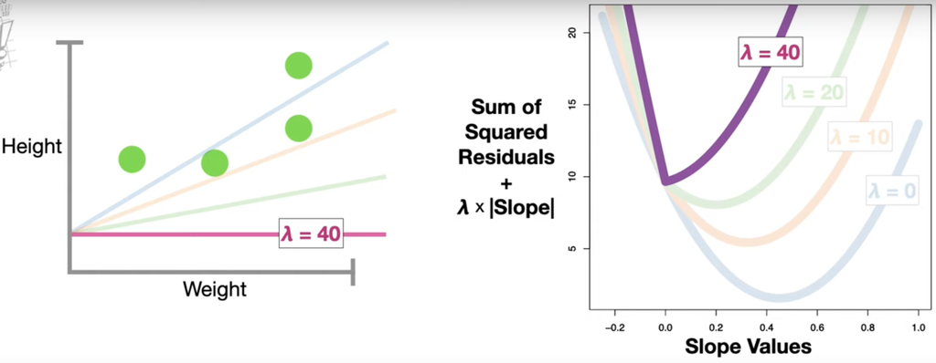

### (L2 Regularization, Ridge):

Efecto en los coeficientes: Ridge penaliza el tamaño de los coeficientes al agregar el cuadrado de sus magnitudes a la función de costo. Esto significa que se reducen los coeficientes grandes, pero ninguno se vuelve exactamente cero.

- Razón: La función cuadrática nunca puede ser cero a menos que el coeficiente también lo sea, pero Ridge favorece soluciones donde todos los coeficientes tienen algún peso. Ejemplo: Si tienes muchas características que aportan información útil, pero algunas tienen más influencia que otras, Ridge ajustará los coeficientes para que no dominen, permitiendo que el modelo sea más estable y menos propenso al sobreajuste (overfitting).
- Beneficio: En situaciones donde todas las variables aportan algo al modelo (aunque sea marginal), Ridge asegura que todas permanezcan. Esto es útil en dominios donde eliminar variables puede ser costoso o donde el conocimiento experto sugiere que cada variable tiene algún valor predictivo.

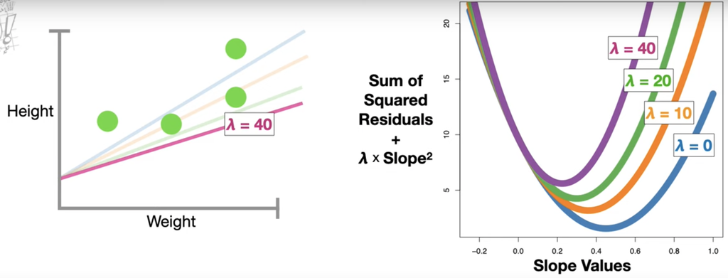

## 4.1.2. - Ridge

```python
## C = 1/ Lambda
## threshold --> el umbral de los coeficientes (w)
## weighted_class = 'balanced', al final del notebook he explicado porque he decidido no usarlo

sel_ridge = SelectFromModel(LogisticRegression(C=1, penalty='l2'), threshold = 0.1)
sel_ridge.fit(X_train_scaled, y_train)
# Si aplicas transform(X_train_scaled, y_train) y transform(X_test_scaled, y_test), filtra las variables seleccionadas
```

```
SelectFromModel(estimator=LogisticRegression(C=1), threshold=0.1)
```

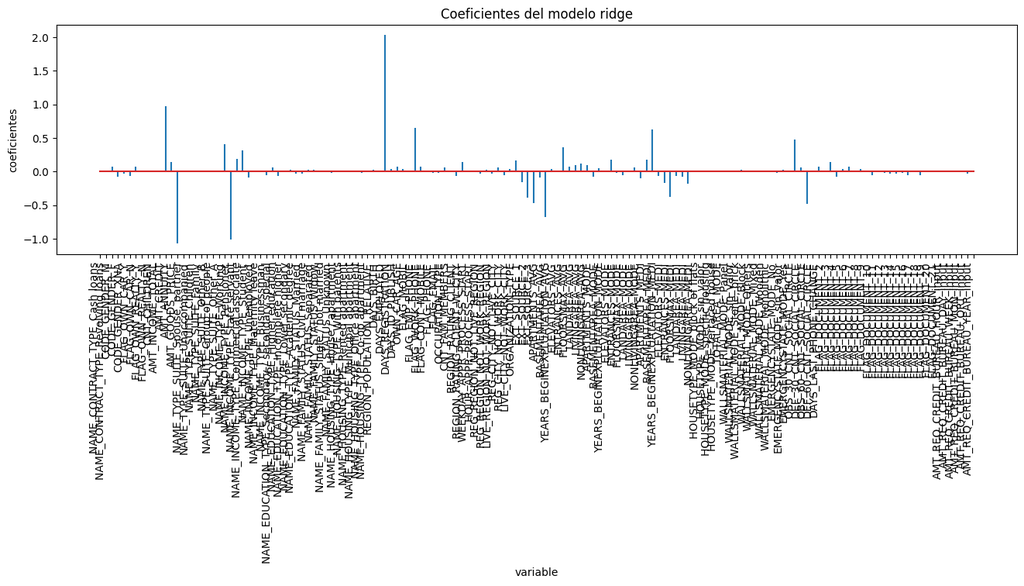

```python
df_coeficientes = pd.DataFrame(
                        {'predictor': X_train_scaled.columns,
                         'coef': sel_ridge.estimator_.coef_.flatten()}
                  )


## Graficamos los coeficientes del modelo
fig, ax = plt.subplots(figsize=(16, 3.84))
ax.stem(df_coeficientes.predictor, df_coeficientes.coef, markerfmt=' ')
plt.xticks(rotation=90, ha='right', size=10)
ax.set_xlabel('variable')
ax.set_ylabel('coeficientes')
ax.set_title('Coeficientes del modelo ridge');
```

```python
sel_ridge.get_support() ## Seleccionamos las variables más relevantes con un array de booleannos
selected_feat_ridge = X_train_scaled.columns[sel_ridge.get_support()]
selected_feat_ridge
```

```
Index(['AMT_CREDIT', 'AMT_ANNUITY', 'AMT_GOODS_PRICE',
       'NAME_INCOME_TYPE_Working', 'NAME_INCOME_TYPE_Pensioner',
       'NAME_INCOME_TYPE_State servant',
       'NAME_INCOME_TYPE_Commercial associate', 'DAYS_EMPLOYED',
       'FLAG_EMP_PHONE', 'REGION_RATING_CLIENT_W_CITY', 'ORGANIZATION_TYPE',
       'EXT_SOURCE_1', 'EXT_SOURCE_2', 'EXT_SOURCE_3', 'BASEMENTAREA_AVG',
       'ENTRANCES_AVG', 'LIVINGAREA_AVG', 'ELEVATORS_MODE', 'APARTMENTS_MEDI',
       'BASEMENTAREA_MEDI', 'ELEVATORS_MEDI', 'ENTRANCES_MEDI',
       'LIVINGAREA_MEDI', 'OBS_30_CNT_SOCIAL_CIRCLE',
       'OBS_60_CNT_SOCIAL_CIRCLE', 'FLAG_DOCUMENT_3'],
      dtype='object')
```

```python
print('total features: {}'.format((X_train_scaled.shape[1])))
print('selected features: {}'.format(len(selected_feat_ridge)))
```

```
total features: 148
selected features: 26
```

## 4.1.1. - Lasso

```python
sel_lasso = SelectFromModel(LogisticRegression(C= 1, penalty='l1',
                                               solver='saga', class_weight='balanced', random_state=123), threshold=0.1)
sel_lasso.fit(X_train_scaled, y_train)
```

```
SelectFromModel(estimator=LogisticRegression(C=1, class_weight='balanced',
                                             penalty='l1', random_state=123,
                                             solver='saga'),
                threshold=0.1)
```

```python
selected_feat_lasso = X_train_scaled.columns[sel_lasso.get_support()]
selected_feat_lasso
```

```
Index(['AMT_CREDIT', 'AMT_ANNUITY', 'AMT_GOODS_PRICE',
       'REGION_RATING_CLIENT_W_CITY', 'ORGANIZATION_TYPE', 'EXT_SOURCE_1',
       'EXT_SOURCE_2', 'EXT_SOURCE_3', 'FLAG_DOCUMENT_3'],
      dtype='object')
```

```python
print('total features: {}'.format((X_train_scaled.shape[1])))
print('selected features: {}'.format(len(selected_feat_lasso)))
```

```
total features: 148
selected features: 9
```

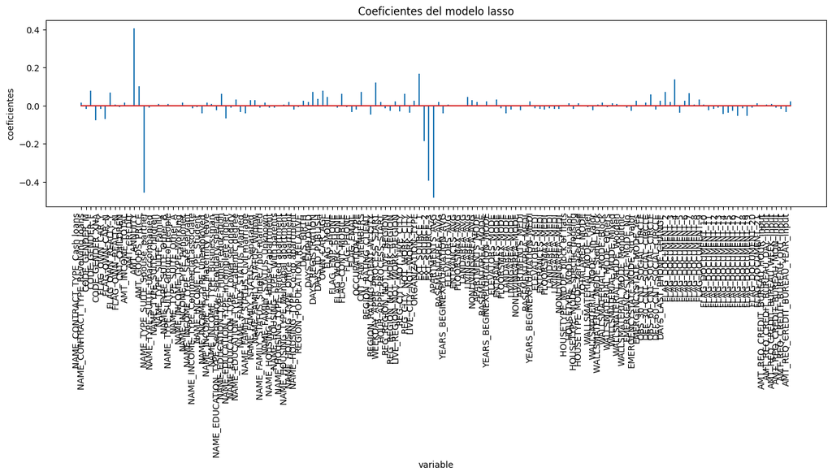

```python
# Coeficientes del modelo
# ==============================================================================
df_coeficientes_lasso = pd.DataFrame(
    {'predictor': X_train_scaled.columns,
     'coef': sel_lasso.estimator_.coef_.flatten()}
     )


fig, ax = plt.subplots(figsize=(16, 3.84))
ax.stem(df_coeficientes_lasso.predictor, df_coeficientes_lasso.coef, markerfmt=' ')
plt.xticks(rotation=90, ha='right', size=10)
ax.set_xlabel('variable')
ax.set_ylabel('coeficientes')
ax.set_title('Coeficientes del modelo lasso');
```

## 4.1.3 ElasticNet

El propósito fundamental de ElasticNet es realizar regresión regularizada combinando las propiedades de Ridge y Lasso para manejar datasets con muchas características, especialmente cuando:

1. Existen características correlacionadas: En casos donde varias variables están fuertemente correlacionadas, ElasticNet puede seleccionar más de una característica relevante del grupo, a diferencia de Lasso, que suele seleccionar solo una.
2. El número de características es mayor que el número de observaciones: En datasets con muchas variables y pocos datos, ElasticNet ayuda a evitar el sobreajuste.
3. Se busca un modelo robusto y parsimonioso: ElasticNet no solo predice bien (robustez) sino que también puede eliminar características irrelevantes (parsimonia), gracias a su componente 𝐿1.

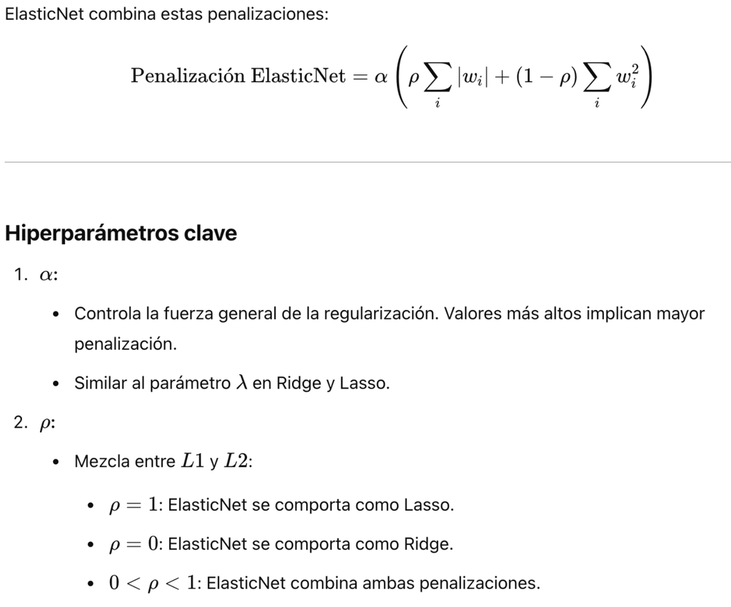

```python
sel_elas = SelectFromModel(LogisticRegression(C= 1, penalty='elasticnet', l1_ratio=0.7,
                                               solver='saga', class_weight='balanced', random_state=123), threshold=0.05)
sel_elas.fit(X_train_scaled, y_train)
```

```
SelectFromModel(estimator=LogisticRegression(C=1, class_weight='balanced',
                                             l1_ratio=0.7, penalty='elasticnet',
                                             random_state=123, solver='saga'),
                threshold=0.05)
```

```python
selected_feat_elas = X_train_scaled.columns[sel_elas.get_support()]
selected_feat_elas
```

```
Index(['CODE_GENDER_M', 'CODE_GENDER_F', 'FLAG_OWN_CAR_Y', 'FLAG_OWN_CAR_N',
       'AMT_CREDIT', 'AMT_ANNUITY', 'AMT_GOODS_PRICE',
       'NAME_EDUCATION_TYPE_Secondary / secondary special',
       'NAME_EDUCATION_TYPE_Higher education', 'DAYS_EMPLOYED',
       'DAYS_ID_PUBLISH', 'FLAG_WORK_PHONE', 'OCCUPATION_TYPE',
       'REGION_RATING_CLIENT_W_CITY', 'REG_CITY_NOT_LIVE_CITY',
       'ORGANIZATION_TYPE', 'EXT_SOURCE_1', 'EXT_SOURCE_2', 'EXT_SOURCE_3',
       'DEF_30_CNT_SOCIAL_CIRCLE', 'DAYS_LAST_PHONE_CHANGE', 'FLAG_DOCUMENT_3',
       'FLAG_DOCUMENT_6', 'FLAG_DOCUMENT_16', 'FLAG_DOCUMENT_18'],
      dtype='object')
```

```python
print('total features: {}'.format((X_train_scaled.shape[1])))
print('selected features: {}'.format(len(selected_feat_elas)))
```

```
total features: 148
selected features: 25
```

## Recursive Feature Elimination (RFE)

RFE (Recursive Feature Elimination, o Eliminación Recursiva de Características) es una técnica de selección de características que elimina recursivamente las menos importantes con el objetivo de reducir el conjunto de características a las más relevantes para un modelo predictivo.

Ventajas:

- Puede utilizarse con cualquier modelo que presente coeficientes (Regresión lineal, Random Forest,...)
- Se puede determinar el número de variables finales que quieres, esto mismo no se puede hacer con los métodos anteriores.

Desventajas:

- Costoso a nivel de computación y tiempo
- Si 2 variables están altamente correlacionadas y son importantes puede eliminar una de ellas debido a como calcula la importancia de las características
- No garantiza una solución global optima. Puede quedarse atrapado en un subconjunto localmente óptimo.
- Si el modelo base no captura relaciones complejas (modelo lineal), no detectetará relaciones no lineales de características importantes.

```python
# feature extraction
model = DecisionTreeClassifier(random_state=123)
# model = RandomForestClassifier()
rfe = RFE(model, n_features_to_select=20, verbose=1) #verbose=1 para ver iterativamente que pasa,
# n_features_to_select: por defecto se selecciona la mitad si no pones este parámetro , n_features_to_select=30
fit = rfe.fit(X_train_scaled, y_train)


print("Num Features: %d" % fit.n_features_)
print("Selected Features: %s" % fit.support_)
print("Feature Ranking: %s" % fit.ranking_)
```

```
Fitting estimator with 148 features.
```

```
Fitting estimator with 147 features.
```

```
Fitting estimator with 146 features.
```

```
Fitting estimator with 145 features.
```

```
Fitting estimator with 144 features.
```

```
Fitting estimator with 143 features.
```

```
Fitting estimator with 142 features.
```

```
Fitting estimator with 141 features.
```

```
Fitting estimator with 140 features.
```

```
Fitting estimator with 139 features.
```

```
Fitting estimator with 138 features.
```

```
Fitting estimator with 137 features.
```

```
Fitting estimator with 136 features.
```

```
Fitting estimator with 135 features.
```

```
Fitting estimator with 134 features.
```

```
Fitting estimator with 133 features.
```

```
Fitting estimator with 132 features.
```

```
Fitting estimator with 131 features.
```

```
Fitting estimator with 130 features.
```

```
Fitting estimator with 129 features.
```

```
Fitting estimator with 128 features.
```

```
Fitting estimator with 127 features.
```

```
Fitting estimator with 126 features.
```

```
Fitting estimator with 125 features.
```

```
Fitting estimator with 124 features.
```

```
Fitting estimator with 123 features.
```

```
Fitting estimator with 122 features.
```

```
Fitting estimator with 121 features.
```

```
Fitting estimator with 120 features.
```

```
Fitting estimator with 119 features.
```

```
Fitting estimator with 118 features.
```

```
Fitting estimator with 117 features.
```

```
Fitting estimator with 116 features.
```

```
Fitting estimator with 115 features.
```

```
Fitting estimator with 114 features.
```

```
Fitting estimator with 113 features.
```

```
Fitting estimator with 112 features.
```

```
Fitting estimator with 111 features.
```

```
Fitting estimator with 110 features.
```

```
Fitting estimator with 109 features.
```

```
Fitting estimator with 108 features.
```

```
Fitting estimator with 107 features.
```

```
Fitting estimator with 106 features.
```

```
Fitting estimator with 105 features.
```

```
Fitting estimator with 104 features.
```

```
Fitting estimator with 103 features.
```

```
Fitting estimator with 102 features.
```

```
Fitting estimator with 101 features.
```

```
Fitting estimator with 100 features.
```

```
Fitting estimator with 99 features.
```

```
Fitting estimator with 98 features.
```

```
Fitting estimator with 97 features.
```

```
Fitting estimator with 96 features.
```

```
Fitting estimator with 95 features.
```

```
Fitting estimator with 94 features.
```

```
Fitting estimator with 93 features.
```

```
Fitting estimator with 92 features.
```

```
Fitting estimator with 91 features.
```

```
Fitting estimator with 90 features.
```

```
Fitting estimator with 89 features.
```

```
Fitting estimator with 88 features.
```

```
Fitting estimator with 87 features.
```

```
Fitting estimator with 86 features.
```

```
Fitting estimator with 85 features.
```

```
Fitting estimator with 84 features.
```

```
Fitting estimator with 83 features.
```

```
Fitting estimator with 82 features.
```

```
Fitting estimator with 81 features.
```

```
Fitting estimator with 80 features.
```

```
Fitting estimator with 79 features.
```

```
Fitting estimator with 78 features.
```

```
Fitting estimator with 77 features.
```

```
Fitting estimator with 76 features.
```

```
Fitting estimator with 75 features.
```

```
Fitting estimator with 74 features.
```

```
Fitting estimator with 73 features.
```

```
Fitting estimator with 72 features.
```

```
Fitting estimator with 71 features.
```

```
Fitting estimator with 70 features.
```

```
Fitting estimator with 69 features.
```

```
Fitting estimator with 68 features.
```

```
Fitting estimator with 67 features.
```

```
Fitting estimator with 66 features.
```

```
Fitting estimator with 65 features.
```

```
Fitting estimator with 64 features.
```

```
Fitting estimator with 63 features.
```

```
Fitting estimator with 62 features.
```

```
Fitting estimator with 61 features.
```

```
Fitting estimator with 60 features.
```

```
Fitting estimator with 59 features.
```

```
Fitting estimator with 58 features.
```

```
Fitting estimator with 57 features.
```

```
Fitting estimator with 56 features.
```

```
Fitting estimator with 55 features.
```

```
Fitting estimator with 54 features.
```

```
Fitting estimator with 53 features.
```

```
Fitting estimator with 52 features.
```

```
Fitting estimator with 51 features.
```

```
Fitting estimator with 50 features.
```

```
Fitting estimator with 49 features.
```

```
Fitting estimator with 48 features.
```

```
Fitting estimator with 47 features.
```

```
Fitting estimator with 46 features.
```

```
Fitting estimator with 45 features.
```

```
Fitting estimator with 44 features.
```

```
Fitting estimator with 43 features.
```

```
Fitting estimator with 42 features.
```

```
Fitting estimator with 41 features.
```

```
Fitting estimator with 40 features.
```

```
Fitting estimator with 39 features.
```

```
Fitting estimator with 38 features.
```

```
Fitting estimator with 37 features.
```

```
Fitting estimator with 36 features.
```

```
Fitting estimator with 35 features.
```

```
Fitting estimator with 34 features.
```

```
Fitting estimator with 33 features.
```

```
Fitting estimator with 32 features.
```

```
Fitting estimator with 31 features.
```

```
Fitting estimator with 30 features.
```

```
Fitting estimator with 29 features.
```

```
Fitting estimator with 28 features.
```

```
Fitting estimator with 27 features.
```

```
Fitting estimator with 26 features.
```

```
Fitting estimator with 25 features.
```

```
Fitting estimator with 24 features.
```

```
Fitting estimator with 23 features.
```

```
Fitting estimator with 22 features.
```

```
Fitting estimator with 21 features.
```

```
Num Features: 20
Selected Features: [False False False False False False False False False False  True  True
  True  True False False False False False False False False False False
 False False False False False False False False False False False False
 False False False False False False False False False False  True  True
  True  True  True  True False False False False False False  True False
 False False False  True False False False False False False  True  True
  True  True False False False False False False False  True False False
 False  True False False False False False False False False False False
 False False False False False False False False False  True False False
 False False False False False False False False False False False False
 False  True False False False False False False False False False False
 False False False False False False False False False False False False
 False False False False]
Feature Ranking: [ 78  94  56  39 123  66  48  58  44  26   1   1   1   1  59  54  70  33
  88 103  96  55 107  64  42 120 117 121 125  46  61  76  63 126  53  37
  45  68  40 127  49  65  69  71  84 104   1   1   1   1   1   1 128 101
  36 106  34  57   1   8  38  23   5   1  81  73  50  35  47  31   1   1
   1   1   9  15  17  86  12  29   3   1   6  28   7   1  91  25  67  14
  21  19  22  27  10  75  52  51  24  13  30  92  95  82 105   1  72  77
  89  79  90  93  99 109  62  87 108  11  18   2  32   1 112  43 124  80
  85 119  83  98 122 110 129 102 115 113 100 116  97 114 118 111  60  74
  41  16  20   4]
```

```python
print(len(X_train_scaled.columns[fit.support_]), len(X_train_scaled.columns))
```

```
20 148
```

```python
X_train_scaled.columns[fit.support_]
```

```
Index(['AMT_INCOME_TOTAL', 'AMT_CREDIT', 'AMT_ANNUITY', 'AMT_GOODS_PRICE',
       'REGION_POPULATION_RELATIVE', 'DAYS_BIRTH', 'DAYS_EMPLOYED',
       'DAYS_REGISTRATION', 'DAYS_ID_PUBLISH', 'OWN_CAR_AGE',
       'OCCUPATION_TYPE', 'HOUR_APPR_PROCESS_START', 'ORGANIZATION_TYPE',
       'EXT_SOURCE_1', 'EXT_SOURCE_2', 'EXT_SOURCE_3', 'LIVINGAREA_AVG',
       'YEARS_BEGINEXPLUATATION_MODE', 'TOTALAREA_MODE',
       'DAYS_LAST_PHONE_CHANGE'],
      dtype='object')
```

```python
## Se toma la selección del RFE ejecutado arriba (antes estaba copiada a mano de una ejecución anterior)
selected_feat_rfe = list(X_train_scaled.columns[fit.support_])
_seleccion_rfe_original = [
    'SK_ID_CURR', 'AMT_INCOME_TOTAL', 'AMT_CREDIT', 'AMT_ANNUITY',
    'AMT_GOODS_PRICE', 'REGION_POPULATION_RELATIVE', 'DAYS_BIRTH',
    'DAYS_EMPLOYED', 'DAYS_REGISTRATION', 'DAYS_ID_PUBLISH',
    'OCCUPATION_TYPE', 'HOUR_APPR_PROCESS_START', 'ORGANIZATION_TYPE',
    'EXT_SOURCE_1', 'EXT_SOURCE_2', 'EXT_SOURCE_3',
    'YEARS_BEGINEXPLUATATION_AVG', 'LANDAREA_AVG', 'LIVINGAREA_MODE',
    'DAYS_LAST_PHONE_CHANGE'
]
```

# Boruta

El propósito fundamental de Boruta es identificar las variables realmente relevantes para un modelo predictivo al comparar su importancia con la de versiones aleatorizadas de las mismas (shadow features). De esta forma, garantiza que las variables seleccionadas aporten información significativa más allá del ruido o el azar, optimizando la calidad del modelo y reduciendo la dimensionalidad del conjunto de datos.

1. Crear shadow features Se generan shadow features, que son copias aleatorizadas de las características originales. Estas mantienen la misma distribución estadística que las originales, pero sus valores están completamente desordenados. Estas características sirven como referencia (benchmark) para medir si las variables originales son más relevantes que el ruido.
2. Entrenar un modelo Random Forest Se entrena un modelo Random Forest utilizando las características originales y las shadow features. Este modelo estima la importancia de cada variable según su capacidad para reducir la impureza (como el Gini o entropía) en los árboles de decisión.
3. Evaluar la importancia de las variables Tras el entrenamiento, se obtiene la importancia de cada característica (original y shadow) en el modelo. Se identifica la shadow feature más importante para usarla como referencia en las comparaciones posteriores. Cada característica original se compara con la shadow feature más importante:
   - Relevante: Si una variable original tiene mayor importancia que la mejor shadow feature de forma consistente.
   - Irrelevante: Si una variable tiene igual o menor importancia que la mejor shadow feature.
   - Tentativa: Si no se puede determinar claramente su relevancia en esta iteración.
4. Iteración y selección Este proceso se repite de forma iterativa para aumentar la confianza de los resultados

```python
## Como 'np.int' fue depreciado en Numpy 1.2 y eliminado en NumPy 1.24, lo que he hecho es asignar el valor que tiene actual
## actualmente a estos casos, así al llamar al boruta lo entiende con los valores correctos.
np.int = np.int32
np.float = np.float64
np.bool = np.bool_
```

```python
# sampling in proportion to y labels
modelo = RandomForestClassifier(n_jobs=-1, max_depth=5) # cambiar los hiperparametros

# define Boruta feature selection method
feat_selector = BorutaPy(modelo, n_estimators='auto', verbose=2, random_state=1, max_iter=100)
    # de base max_iter = 100

# find all relevant features - 5 features should be selected
feat_selector.fit(X_train_scaled.values, y_train.values) # Importante poner el .values al dataframe, sino dará error

# check selected features - first 5 features are selected
feat_selector.support_

# check ranking of features
feat_selector.ranking_
```

```
Iteration: 	1 / 100
Confirmed: 	0
Tentative: 	148
Rejected: 	0
```

```
Iteration: 	2 / 100
Confirmed: 	0
Tentative: 	148
Rejected: 	0
```

```
Iteration: 	3 / 100
Confirmed: 	0
Tentative: 	148
Rejected: 	0
```

```
Iteration: 	4 / 100
Confirmed: 	0
Tentative: 	148
Rejected: 	0
```

```
Iteration: 	5 / 100
Confirmed: 	0
Tentative: 	148
Rejected: 	0
```

```
Iteration: 	6 / 100
Confirmed: 	0
Tentative: 	148
Rejected: 	0
```

```
Iteration: 	7 / 100
Confirmed: 	0
Tentative: 	148
Rejected: 	0
```

```
Iteration: 	8 / 100
Confirmed: 	55
Tentative: 	16
Rejected: 	77
```

```
Iteration: 	9 / 100
Confirmed: 	55
Tentative: 	16
Rejected: 	77
```

```
Iteration: 	10 / 100
Confirmed: 	55
Tentative: 	16
Rejected: 	77
```

```
Iteration: 	11 / 100
Confirmed: 	55
Tentative: 	16
Rejected: 	77
```

```
Iteration: 	12 / 100
Confirmed: 	57
Tentative: 	9
Rejected: 	82
```

```
Iteration: 	13 / 100
Confirmed: 	57
Tentative: 	9
Rejected: 	82
```

```
Iteration: 	14 / 100
Confirmed: 	57
Tentative: 	9
Rejected: 	82
```

```
Iteration: 	15 / 100
Confirmed: 	57
Tentative: 	9
Rejected: 	82
```

```
Iteration: 	16 / 100
Confirmed: 	57
Tentative: 	9
Rejected: 	82
```

```
Iteration: 	17 / 100
Confirmed: 	57
Tentative: 	9
Rejected: 	82
```

```
Iteration: 	18 / 100
Confirmed: 	57
Tentative: 	9
Rejected: 	82
```

```
Iteration: 	19 / 100
Confirmed: 	57
Tentative: 	9
Rejected: 	82
```

```
Iteration: 	20 / 100
Confirmed: 	57
Tentative: 	9
Rejected: 	82
```

```
Iteration: 	21 / 100
Confirmed: 	57
Tentative: 	9
Rejected: 	82
```

```
Iteration: 	22 / 100
Confirmed: 	57
Tentative: 	9
Rejected: 	82
```

```
Iteration: 	23 / 100
Confirmed: 	57
Tentative: 	7
Rejected: 	84
```

```
Iteration: 	24 / 100
Confirmed: 	57
Tentative: 	7
Rejected: 	84
```

```
Iteration: 	25 / 100
Confirmed: 	57
Tentative: 	7
Rejected: 	84
```

```
Iteration: 	26 / 100
Confirmed: 	57
Tentative: 	7
Rejected: 	84
```

```
Iteration: 	27 / 100
Confirmed: 	57
Tentative: 	7
Rejected: 	84
```

```
Iteration: 	28 / 100
Confirmed: 	57
Tentative: 	7
Rejected: 	84
```

```
Iteration: 	29 / 100
Confirmed: 	57
Tentative: 	7
Rejected: 	84
```

```
Iteration: 	30 / 100
Confirmed: 	57
Tentative: 	7
Rejected: 	84
```

```
Iteration: 	31 / 100
Confirmed: 	57
Tentative: 	7
Rejected: 	84
```

```
Iteration: 	32 / 100
Confirmed: 	57
Tentative: 	4
Rejected: 	87
```

```
Iteration: 	33 / 100
Confirmed: 	57
Tentative: 	4
Rejected: 	87
```

```
Iteration: 	34 / 100
Confirmed: 	57
Tentative: 	4
Rejected: 	87
```

```
Iteration: 	35 / 100
Confirmed: 	57
Tentative: 	4
Rejected: 	87
```

```
Iteration: 	36 / 100
Confirmed: 	57
Tentative: 	4
Rejected: 	87
```

```
Iteration: 	37 / 100
Confirmed: 	57
Tentative: 	4
Rejected: 	87
```

```
Iteration: 	38 / 100
Confirmed: 	57
Tentative: 	4
Rejected: 	87
```

```
Iteration: 	39 / 100
Confirmed: 	57
Tentative: 	4
Rejected: 	87
```

```
Iteration: 	40 / 100
Confirmed: 	57
Tentative: 	4
Rejected: 	87
```

```
Iteration: 	41 / 100
Confirmed: 	57
Tentative: 	4
Rejected: 	87
```

```
Iteration: 	42 / 100
Confirmed: 	57
Tentative: 	4
Rejected: 	87
```

```
Iteration: 	43 / 100
Confirmed: 	57
Tentative: 	4
Rejected: 	87
```

```
Iteration: 	44 / 100
Confirmed: 	57
Tentative: 	4
Rejected: 	87
```

```
Iteration: 	45 / 100
Confirmed: 	57
Tentative: 	4
Rejected: 	87
```

```
Iteration: 	46 / 100
Confirmed: 	57
Tentative: 	4
Rejected: 	87
```

```
Iteration: 	47 / 100
Confirmed: 	57
Tentative: 	4
Rejected: 	87
```

```
Iteration: 	48 / 100
Confirmed: 	57
Tentative: 	4
Rejected: 	87
```

```
Iteration: 	49 / 100
Confirmed: 	57
Tentative: 	4
Rejected: 	87
```

```
Iteration: 	50 / 100
Confirmed: 	57
Tentative: 	4
Rejected: 	87
```

```
Iteration: 	51 / 100
Confirmed: 	57
Tentative: 	4
Rejected: 	87
```

```
Iteration: 	52 / 100
Confirmed: 	57
Tentative: 	4
Rejected: 	87
```

```
Iteration: 	53 / 100
Confirmed: 	57
Tentative: 	4
Rejected: 	87
```

```
Iteration: 	54 / 100
Confirmed: 	57
Tentative: 	3
Rejected: 	88
```

```
Iteration: 	55 / 100
Confirmed: 	57
Tentative: 	3
Rejected: 	88
```

```
Iteration: 	56 / 100
Confirmed: 	57
Tentative: 	3
Rejected: 	88
```

```
Iteration: 	57 / 100
Confirmed: 	57
Tentative: 	3
Rejected: 	88
```

```
Iteration: 	58 / 100
Confirmed: 	57
Tentative: 	3
Rejected: 	88
```

```
Iteration: 	59 / 100
Confirmed: 	57
Tentative: 	3
Rejected: 	88
```

```
Iteration: 	60 / 100
Confirmed: 	57
Tentative: 	3
Rejected: 	88
```

```
Iteration: 	61 / 100
Confirmed: 	57
Tentative: 	3
Rejected: 	88
```

```
Iteration: 	62 / 100
Confirmed: 	57
Tentative: 	3
Rejected: 	88
```

```
Iteration: 	63 / 100
Confirmed: 	57
Tentative: 	3
Rejected: 	88
```

```
Iteration: 	64 / 100
Confirmed: 	57
Tentative: 	3
Rejected: 	88
```

```
Iteration: 	65 / 100
Confirmed: 	57
Tentative: 	3
Rejected: 	88
```

```
Iteration: 	66 / 100
Confirmed: 	57
Tentative: 	3
Rejected: 	88
```

```
Iteration: 	67 / 100
Confirmed: 	57
Tentative: 	3
Rejected: 	88
```

```
Iteration: 	68 / 100
Confirmed: 	57
Tentative: 	3
Rejected: 	88
```

```
Iteration: 	69 / 100
Confirmed: 	57
Tentative: 	3
Rejected: 	88
```

```
Iteration: 	70 / 100
Confirmed: 	57
Tentative: 	3
Rejected: 	88
```

```
Iteration: 	71 / 100
Confirmed: 	57
Tentative: 	3
Rejected: 	88
```

```
Iteration: 	72 / 100
Confirmed: 	57
Tentative: 	3
Rejected: 	88
```

```
Iteration: 	73 / 100
Confirmed: 	57
Tentative: 	3
Rejected: 	88
```

```
Iteration: 	74 / 100
Confirmed: 	57
Tentative: 	3
Rejected: 	88
```

```
Iteration: 	75 / 100
Confirmed: 	57
Tentative: 	3
Rejected: 	88
```

```
Iteration: 	76 / 100
Confirmed: 	57
Tentative: 	3
Rejected: 	88
```

```
Iteration: 	77 / 100
Confirmed: 	57
Tentative: 	3
Rejected: 	88
```

```
Iteration: 	78 / 100
Confirmed: 	57
Tentative: 	3
Rejected: 	88
```

```
Iteration: 	79 / 100
Confirmed: 	57
Tentative: 	3
Rejected: 	88
```

```
Iteration: 	80 / 100
Confirmed: 	57
Tentative: 	3
Rejected: 	88
```

```
Iteration: 	81 / 100
Confirmed: 	57
Tentative: 	3
Rejected: 	88
```

```
Iteration: 	82 / 100
Confirmed: 	57
Tentative: 	3
Rejected: 	88
```

```
Iteration: 	83 / 100
Confirmed: 	57
Tentative: 	3
Rejected: 	88
```

```
Iteration: 	84 / 100
Confirmed: 	57
Tentative: 	3
Rejected: 	88
```

```
Iteration: 	85 / 100
Confirmed: 	57
Tentative: 	3
Rejected: 	88
```

```
Iteration: 	86 / 100
Confirmed: 	57
Tentative: 	3
Rejected: 	88
```

```
Iteration: 	87 / 100
Confirmed: 	57
Tentative: 	3
Rejected: 	88
```

```
Iteration: 	88 / 100
Confirmed: 	57
Tentative: 	3
Rejected: 	88
```

```
Iteration: 	89 / 100
Confirmed: 	57
Tentative: 	3
Rejected: 	88
```

```
Iteration: 	90 / 100
Confirmed: 	57
Tentative: 	3
Rejected: 	88
```

```
Iteration: 	91 / 100
Confirmed: 	57
Tentative: 	3
Rejected: 	88
```

```
Iteration: 	92 / 100
Confirmed: 	57
Tentative: 	3
Rejected: 	88
```

```
Iteration: 	93 / 100
Confirmed: 	57
Tentative: 	2
Rejected: 	89
```

```
Iteration: 	94 / 100
Confirmed: 	57
Tentative: 	2
Rejected: 	89
```

```
Iteration: 	95 / 100
Confirmed: 	57
Tentative: 	2
Rejected: 	89
```

```
Iteration: 	96 / 100
Confirmed: 	57
Tentative: 	2
Rejected: 	89
```

```
Iteration: 	97 / 100
Confirmed: 	57
Tentative: 	2
Rejected: 	89
```

```
Iteration: 	98 / 100
Confirmed: 	57
Tentative: 	2
Rejected: 	89
```

```
Iteration: 	99 / 100
Confirmed: 	57
Tentative: 	2
Rejected: 	89


BorutaPy finished running.

Iteration: 	100 / 100
Confirmed: 	57
Tentative: 	1
Rejected: 	89
```

```
array([ 1,  1,  1,  1, 88,  1,  1, 68, 54, 10,  1,  1,  1,  1, 78, 42, 66,
       53, 51, 44, 63,  1,  1, 33, 24, 88, 37, 61, 88,  1,  1, 41, 32, 82,
        1, 28, 46, 41,  7, 88, 12,  9, 35, 68, 75, 47,  1,  1,  1,  1,  1,
        1, 88,  1,  7, 45, 34, 58,  1,  5,  1,  1, 38,  3, 55, 52, 73,  1,
        1, 14,  1,  1,  1,  1,  1, 20,  1,  1, 11,  1, 16,  1, 24,  1, 27,
        1,  1, 24,  1, 17,  1, 19,  2, 22,  1,  1, 27,  1, 14,  1, 29,  1,
        3, 57, 71,  1, 15,  1, 66, 75, 43, 60, 57, 76,  1,  1, 62, 30,  1,
       31,  1,  1, 36,  1, 88, 69,  9, 83, 39, 78, 88, 81, 88, 80, 71, 79,
       48, 71, 60, 64, 50, 49,  1,  1,  1, 21, 19,  4], dtype=int32)
```

```python
selected_feat_boruta = X_train_scaled.columns[feat_selector.support_]
selected_feat_boruta
```

```
Index(['NAME_CONTRACT_TYPE_Cash loans', 'NAME_CONTRACT_TYPE_Revolving loans',
       'CODE_GENDER_M', 'CODE_GENDER_F', 'FLAG_OWN_CAR_Y', 'FLAG_OWN_CAR_N',
       'AMT_INCOME_TOTAL', 'AMT_CREDIT', 'AMT_ANNUITY', 'AMT_GOODS_PRICE',
       'NAME_INCOME_TYPE_Working', 'NAME_INCOME_TYPE_Pensioner',
       'NAME_EDUCATION_TYPE_Secondary / secondary special',
       'NAME_EDUCATION_TYPE_Higher education', 'NAME_FAMILY_STATUS_Married',
       'REGION_POPULATION_RELATIVE', 'DAYS_BIRTH', 'DAYS_EMPLOYED',
       'DAYS_REGISTRATION', 'DAYS_ID_PUBLISH', 'OWN_CAR_AGE', 'FLAG_EMP_PHONE',
       'OCCUPATION_TYPE', 'REGION_RATING_CLIENT',
       'REGION_RATING_CLIENT_W_CITY', 'REG_CITY_NOT_LIVE_CITY',
       'REG_CITY_NOT_WORK_CITY', 'ORGANIZATION_TYPE', 'EXT_SOURCE_1',
       'EXT_SOURCE_2', 'EXT_SOURCE_3', 'APARTMENTS_AVG',
       'YEARS_BEGINEXPLUATATION_AVG', 'ELEVATORS_AVG', 'FLOORSMAX_AVG',
       'LIVINGAREA_AVG', 'APARTMENTS_MODE', 'YEARS_BEGINEXPLUATATION_MODE',
       'ELEVATORS_MODE', 'FLOORSMAX_MODE', 'LIVINGAREA_MODE',
       'YEARS_BEGINEXPLUATATION_MEDI', 'ELEVATORS_MEDI', 'FLOORSMAX_MEDI',
       'LIVINGAREA_MEDI', 'HOUSETYPE_MODE_block of flats', 'TOTALAREA_MODE',
       'WALLSMATERIAL_MODE_sin_valor', 'EMERGENCYSTATE_MODE_No',
       'EMERGENCYSTATE_MODE_sin_valor', 'DEF_30_CNT_SOCIAL_CIRCLE',
       'DEF_60_CNT_SOCIAL_CIRCLE', 'DAYS_LAST_PHONE_CHANGE', 'FLAG_DOCUMENT_3',
       'AMT_REQ_CREDIT_BUREAU_HOUR_input', 'AMT_REQ_CREDIT_BUREAU_DAY_input',
       'AMT_REQ_CREDIT_BUREAU_WEEK_input'],
      dtype='object')
```

One limitation of these metrics is that they assume that the class distribution observed in the training dataset will match the distribution in the test set and in real data when the model is used to make predictions. This is often the case, but when it is not the case, the performance can be quite misleading.

# Breve evaluación de los selectores

> Nota (recuperación, oct. 2026): la comparación se hace ahora sobre una partición de validación extraída de train. Antes se hacía sobre el conjunto de test, que debe quedar reservado para la evaluación final. En las anotaciones de más abajo, las dos primeras configuraciones son pruebas de la ejecución original (evaluadas sobre test); la configuración final (umbral 0.1) está actualizada con los resultados de esta ejecución, sobre validación.

```python
from sklearn.dummy import DummyClassifier  # Para DummyClassifier
from sklearn.naive_bayes import GaussianNB  # Para Gaussian Naive Bayes
from sklearn.metrics import fbeta_score, average_precision_score, accuracy_score, recall_score

selected_features = {
    "Lasso": selected_feat_lasso,
    "Ridge": selected_feat_ridge,
    "RFE": selected_feat_rfe,
    "Boruta": selected_feat_boruta
}

# Variables seleccionadas por Boruta
X_train_boruta = X_train_scaled[selected_feat_boruta]
X_test_boruta = X_test_scaled[selected_feat_boruta]

# Variables seleccionadas por otros métodos
X_train_lasso = X_train_scaled[selected_feat_lasso]
X_test_lasso = X_test_scaled[selected_feat_lasso]

X_train_ridge = X_train_scaled[selected_feat_ridge]
X_test_ridge = X_test_scaled[selected_feat_ridge]

X_train_rfe = X_train_scaled[selected_feat_rfe]
X_test_rfe = X_test_scaled[selected_feat_rfe]


## La comparación de selectores se hace sobre una partición de validación sacada de train;
## el conjunto de test queda reservado para la evaluación final (notebook 05)
from sklearn.model_selection import train_test_split
X_tr_sel, X_val_sel, y_tr_sel, y_val_sel = train_test_split(
    X_train_scaled, y_train, test_size=0.2, stratify=y_train, random_state=123)

models = {
    "Dummy": DummyClassifier(strategy="most_frequent"),
    "Naive Bayes": GaussianNB(),
    "Logistic Regression": LogisticRegression(max_iter=1000, random_state=42),
    "Decision Tree": DecisionTreeClassifier(random_state=123)
}
```

```python
# Lista de modelos representativos
evaluation_results = {}

# Evaluar cada modelo con cada conjunto de características seleccionadas
for model_name, model in models.items():
    evaluation_results[model_name] = {}
    for selector_name, selected_features_list in selected_features.items():
        # Filtrar las características seleccionadas
        X_train_selected = X_tr_sel[selected_features_list]
        X_val_selected = X_val_sel[selected_features_list]

        # Entrenar el modelo
        model.fit(X_train_selected, y_tr_sel)

        # Predecir en el conjunto de validación
        y_pred = model.predict(X_val_selected)
        y_pred_proba = model.predict_proba(X_val_selected)[:, 1]  # Probabilidades (si están disponibles)

        # Calcular métricas
        f2 = fbeta_score(y_val_sel, y_pred, beta=2)
        pr_auc = average_precision_score(y_val_sel, y_pred_proba)
        accuracy = accuracy_score(y_val_sel, y_pred)
        sensitivity = recall_score(y_val_sel, y_pred)  # Sensitividad = Recall

        # Almacenar resultados
        evaluation_results[model_name][selector_name] = {
            "Accuracy": accuracy,
            "Sensitivity": sensitivity,
            "F2-score": f2,
            "PR AUC": pr_auc,
        }
```

```python
# Mostrar resultados
for model_name, scores in evaluation_results.items():
    print(f"Resultados para {model_name}:")
    for selector_name, metrics in scores.items():
        print(f"""{selector_name}:
              Accuracy = {metrics['Accuracy']:.4f},
              Sensitivity = {metrics['Sensitivity']:.4f},
              F2-score = {metrics['F2-score']:.4f},
              PR AUC = {metrics['PR AUC']:.4f}""")
```

```
Resultados para Dummy:
Lasso:
              Accuracy = 0.9193,
              Sensitivity = 0.0000,
              F2-score = 0.0000,
              PR AUC = 0.0807
Ridge:
              Accuracy = 0.9193,
              Sensitivity = 0.0000,
              F2-score = 0.0000,
              PR AUC = 0.0807
RFE:
              Accuracy = 0.9193,
              Sensitivity = 0.0000,
              F2-score = 0.0000,
              PR AUC = 0.0807
Boruta:
              Accuracy = 0.9193,
              Sensitivity = 0.0000,
              F2-score = 0.0000,
              PR AUC = 0.0807
Resultados para Naive Bayes:
Lasso:
              Accuracy = 0.9091,
              Sensitivity = 0.1239,
              F2-score = 0.1416,
              PR AUC = 0.2116
Ridge:
              Accuracy = 0.7337,
              Sensitivity = 0.5222,
              F2-score = 0.3555,
              PR AUC = 0.1885
RFE:
              Accuracy = 0.9081,
              Sensitivity = 0.0541,
              F2-score = 0.0637,
              PR AUC = 0.1671
Boruta:
              Accuracy = 0.7822,
              Sensitivity = 0.4295,
```

[output cut: 29 more lines]

```
Ridge:
              Accuracy = 0.8509,
              Sensitivity = 0.1667,
              F2-score = 0.1609,
              PR AUC = 0.0908
RFE:
              Accuracy = 0.8521,
              Sensitivity = 0.1636,
              F2-score = 0.1586,
              PR AUC = 0.0906
Boruta:
              Accuracy = 0.8518,
              Sensitivity = 0.1712,
              F2-score = 0.1653,
              PR AUC = 0.0918
```

# Inferencia de ir alterando los hiperparámetros de Lasso y Ridge

Resultados para Naive Bayes:

- Lasso: F2-score = 0.2383, PR AUC = 0.1832
- Ridge: F2-score = 0.3070, PR AUC = 0.0830

Resultados para Logistic Regression:

- Lasso: F2-score = 0.0098, PR AUC = 0.2119
- Ridge: F2-score = 0.0110, PR AUC = 0.2162

Resultados para Decision Tree:

- Lasso: F2-score = 0.1573, PR AUC = 0.0904
- Ridge: F2-score = 0.1618, PR AUC = 0.0907

### 1. (LogisticRegression(C= 1, penalty='l1', solver='saga'), threshold=0.05) --> 20 variables

### 2. (LogisticRegression(C=1, penalty='l2'), threshold = 0.06) --> 43 variables

- Aumentar el threshold de l2 ha tenido un efecto significativo en Naive Bayes

Resultados para Naive Bayes:

- Lasso: F2-score = 0.2383, PR AUC = 0.1832
- Ridge: F2-score = 0.3075, PR AUC = 0.1794

Resultados para Logistic Regression:

- Lasso: F2-score = 0.0098, PR AUC = 0.2119
- Ridge: F2-score = 0.0118, PR AUC = 0.2129

Resultados para Decision Tree:

- Lasso: F2-score = 0.1626, PR AUC = 0.0912
- Ridge: F2-score = 0.1584, PR AUC = 0.0899

### 1. (LogisticRegression(C= 1, penalty='l1', solver='saga', class_weight='balanced'), threshold=0.1) --> 9 variables

### 2. (LogisticRegression(C=1, penalty='l2'), threshold = 0.1) --> 26 variables

Resultados para Naive Bayes:

- Lasso: F2-score = 0.1416, PR AUC = 0.2116
- Ridge: F2-score = 0.3555, PR AUC = 0.1885

Resultados para Logistic Regression:

- Lasso: F2-score = 0.0107, PR AUC = 0.2189
- Ridge: F2-score = 0.0135, PR AUC = 0.2199

Resultados para Decision Tree:

- Lasso: F2-score = 0.1648, PR AUC = 0.0921
- Ridge: F2-score = 0.1609, PR AUC = 0.0908

## Evaluación

Lo que he hecho es entrenar una serie de modelos básicos para probar que tan buenos resultados dan dependiendo de la selección de variables. Para comprobar la efectividad de estos, he calculado de diferentes métricas:

- Accuracy. Aunque en este hay que tener cuidado, ya que tenemos una muestra desbalanceada, siempre es útil ponerla para poder comprender el 'trade-off' que estamos haciendo cuando alguna métrica mejora.
- Senstivity. Esta métrica es idónea para el caso, además es la más sencilla de interpretar para ver como de bien se predice la clase minoritaria
- F2-Score. Esta medida mezcla precisión y recall, dando una visión más general de la eficiencia conseguida.
- PC AUR. Otra forma de analizar los resultados del modelo que se basa en la precision y recall, muy parecida a la anterior.

Para evaluar los modelos me he basado principalmente en la información que podemos encontrar en: https://machinelearningmastery.com/tour-of-evaluation-metrics-for-imbalanced-classification/

Decir también que he ido cambiando los hiperparámetrod de ridge y lasso para ver si estos tienen un impacto significativo en el resultado final. Con el **Boruta** y con **RFE** no lo he hecho por varios motivos.

Son sistemas que para realizar la evaluación de las características se basan en crear subconjuntos de datos de forma iterativa. Esto implica que en datasets grandes, como este (148 variables), necesitan mucho poder de computación, lo que se traduce en tiempo. Esto sumado a que en una primera evaluación he podido ver que el selector ridge da el mejor F2-score (0.36 con Naive Bayes), y que Boruta, con 57 variables, solo mejora ligeramente el PR AUC (0.227 frente a 0.220 con la regresión logística), ha sido suficiente para descartarlos.

Para intentar mejorar un poco los resultados en el proceso de selección, he cambiado los umbrales, en algún caso también el valor de C pero la realidad es que la variación en los estos hiperparámetros no llega a ser sustancial en ningún caso.

También he probado a añadir class_weighted = 'balanced' en los parámetros del modelo. Implicó una ligera mejora en la mayoría de los modelos. Pero en el caso de Naive-Bayes llevo a un overfitting elevadísimo, por lo que he considerado mejor no añadirlo.

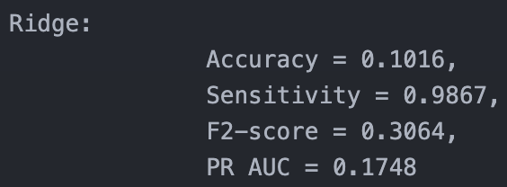

# Almacenado de tablas

```python
X_test_scaled[selected_feat_ridge]
pd.concat([X_train_scaled[selected_feat_ridge], y_train], axis=1).to_csv('../data/processed_data/df_train_scaled.csv', index=False)

X_test_scaled[selected_feat_ridge]
pd.concat([X_test_scaled[selected_feat_ridge], y_test], axis=1).to_csv('../data/processed_data/df_test_scaled.csv', index=False)
```